# Exploratory Analysis of Daily Activities Data

Aria Petrucci

2023-10-17

## About the Data

This exploratory analysis will examine the amount of time T. L. Bailey (2019) spent completing different kinds of activities over a period of 28 days. Each day, Bailey recorded the amount of time they spent completing each of the following activity types: Screen time, social networking, reading/reference, productivity, health/fitness, entertainment, creativity, and “other”. Bailey also indicated whether they practiced yoga each day.

Prior to examining the data, it is clear that the conclusions that can be drawn from this data are limited due to the following limitations of the data set:

1. Data is recorded for only 1 person. This small sample size means it isn’t appropriate to conduct hypothesis testing.
2. Data is recorded for a short period of time, meaning it isn’t possible to meaningfully assess trends across time.
3. The available documentation for the data does not specify the unit of time (minutes, hours, etc.). For the purposes of this analysis, I assume the unit is minutes.
4. The activity types are not clearly defined and may not be mutually exclusive. For example, screen time may include social networking, entertainment, etc.

Data Source: Bailey, T.L. (2019). Screen Time Data. https://data.world/taylynners04

## Load Packages and Import Data

This analysis will require three packages. I’ll use the `tidyverse` packages to process and visualize data, and the `grid` and `gridExtra` packages to arrange plots on a grid.

```r
library(tidyverse)
library(grid)
library(gridExtra)
```

The first step is to import the data, which is saved in a file named `Screen_Time_Data.csv`. I’ll store the data in an object named `activ_data`. The file contains an `index` variable which I assign as the data frame’s row names by setting `row.names = "index"`.

```r
activ_data <- read.csv("Screen_Time_Data.csv",
                       row.names = "index")
```

## Get Acquainted With the Data

Next, I inspect the data. I opt to use tidyverse’s `glimpse` function for this because it returns a preview of the first few observations of data, the data type for each variable, and information about the data frame’s structure such as the number of rows and columns.

```r
glimpse(activ_data)
```

```
## Rows: 28
## Columns: 11
## $ Date                  <chr> "04/17/19", "04/18/19", "04/19/19", "04/20/19", …
## $ Week.Day              <chr> "Wednesday", "Thursday", "Friday", "Saturday", "…
## $ Total.Screen.Time     <int> 187, 123, 112, 101, 56, 189, 158, 135, 52, 198, …
## $ Social.Networking     <int> 89, 78, 52, 69, 35, 68, 56, 98, 25, 76, 75, 42, …
## $ Reading.and.Reference <int> 17, 17, 40, 9, 2, 0, 18, 3, 7, 8, 10, 22, 8, 2, …
## $ Other                 <int> 41, 8, 8, 38, 43, 9, 41, 33, 3, 29, 20, 4, 13, 9…
## $ Productivity          <int> 22, 9, 4, 2, 3, 3, 12, 16, 16, 15, 5, 2, 9, 12, …
## $ Health.and.Fitness    <int> 0, 0, 0, 0, 0, 4, 15, 0, 0, 0, 0, 0, 15, 0, 0, 0…
## $ Entertainment         <int> 0, 0, 3, 3, 1, 0, 0, 0, 0, 32, 0, 0, 1, 0, 0, 0,…
## $ Creativity            <int> 0, 0, 0, 0, 1, 0, 0, 0, 0, 0, 0, 0, 0, 0, 0, 0, …
## $ Yoga                  <int> 0, 0, 0, 0, 0, 0, 0, 0, 0, 0, 0, 0, 1, 1, 1, 1, …
```

I can see that this data frame contains 11 columns. I have access to the date (mm/dd/yy), the day of the week, the daily time spent completing each of the 8 activity types, and a binary variable representing whether yoga was practiced each day. As expected, the data frame contains 28 rows indicating that data is available for 28 days.

The data frame is pretty clean, but some things require attention:

- Column names are delimited by periods where the original csv file contained spaces. For personal preference, I’ll replace all instances of `.` with `_` .
- `Date` contains character data. I’ll convert it to type Date and check for anomalies. This will allow me to extract specific pieces of date-related information from this variable, which will come in handy below…
- `Week.Day` contains character data indicating the day of the week. I could assume that the week day recorded for each date is correct, but instead I’m going to extract the calendar-observed week day associated with each date, which I’ll have access to once the `Date` variable is in Date format, and use those values as `Week.Day`. In doing so, I’ll convert this variable to type factor with one level for each day of the week.
- `Total.Screen.Time` to `Creativity` contain integer data representing time spent on each activity. As previously mentioned, the unit of time is not specified but I assume that it is minutes. I’ll check these variables for anomalies which may suggest a different unit.
- `Total.Screen.Time` follows a naming scheme different from the other variables, so I’ll change the name to `Screen` .
- `Yoga` contains integer data and indicates whether yoga was practiced that day. Because this binary variable represents two levels of a condition, I’ll convert `Yoga` to type factor. Based on the documentation and data, it is apparent that 0 = No (yoga not practiced) and 1 = Yes (yoga practiced). I’ll also check for anomalies, such as the presence of an unexpected third level.

I’ll begin by constructing frequency tables to check for anomalies in the categorical `Date` and `Yoga` variables. I could include the continuous variables here as well, but those frequency tables would be hard to visually scan, so I’m going to check those variables for anomalies later on using histograms and other more appropriate methods.

```r
activ_data %>%
  select(Date, Yoga) %>%
  map(table)
```

```
## $Date
##
## 04/17/19 04/18/19 04/19/19 04/20/19 04/21/19 04/22/19 04/23/19 04/24/19
##        1        1        1        1        1        1        1        1
## 04/25/19 04/26/19 04/27/19 04/28/19 04/29/19 04/30/19 05/01/19 05/02/19
##        1        1        1        1        1        1        1        1
## 05/03/19 05/04/19 05/05/19 05/06/19 05/07/19 05/08/19 05/09/19 05/10/19
##        1        1        1        1        1        1        1        1
## 05/11/19 05/12/19 05/13/19 05/14/19
##        1        1        1        1
##
## $Yoga
##
##  0  1
## 12 16
```

Great! The `$Date` output indicates that each date in this data frame is observed only once, and all dates between April 17th, 2019 and May 14th, 2019 are present. This means that no dates are duplicated or missing, and we have 28 *consecutive* days of data.

The `$Yoga` output confirms that the `Yoga` variable is indeed binary, as only two values (0 and 1) are observed. I can see that there were 12 days when Bailey didn’t practice yoga and 16 days when they did, and that `Yoga` data is present for all 28 days.

Next, I’m going to check the other variables for missing data. The code below will count how many times missing data is observed for each individual variable.

```r
activ_data %>%
  map(c(is.na, sum))
```

```
## $Date
## [1] 0
##
## $Week.Day
## [1] 0
##
## $Total.Screen.Time
## [1] 0
##
## $Social.Networking
## [1] 0
##
## $Reading.and.Reference
## [1] 0
##
## $Other
## [1] 0
##
## $Productivity
## [1] 0
##
## $Health.and.Fitness
## [1] 0
##
## $Entertainment
## [1] 0
##
## $Creativity
## [1] 0
##
## $Yoga
## [1] 0
```

The output shows no missing data in any variable, and I’m going to bask in this beauty for a moment, because it might never happen again!

## Clean the Data

I feel good about the integrity of the data so far, so I’m going to go ahead and start applying the corrections I mentioned above. The code below creates a new data frame named `activ_data_clean` from our existing `activ_data` data frame and applies all necessary corrections in one fell swoop and prints a glimpse of the new, clean data frame.

```r
activ_data_clean <- activ_data %>%
  rename_with(~ str_replace_all(., "\\.", "_")) %>%
  rename(Screen = Total_Screen_Time) %>%
  mutate(Date = mdy(Date)) %>%
  mutate(Week_Day = wday(Date, label = TRUE)) %>%
  mutate(Yoga = factor(Yoga, labels = c("No","Yes"))) %>%
  glimpse()
```

```
## Rows: 28
## Columns: 11
## $ Date                  <date> 2019-04-17, 2019-04-18, 2019-04-19, 2019-04-20,…
## $ Week_Day              <ord> Wed, Thu, Fri, Sat, Sun, Mon, Tue, Wed, Thu, Fri…
## $ Screen                <int> 187, 123, 112, 101, 56, 189, 158, 135, 52, 198, …
## $ Social_Networking     <int> 89, 78, 52, 69, 35, 68, 56, 98, 25, 76, 75, 42, …
## $ Reading_and_Reference <int> 17, 17, 40, 9, 2, 0, 18, 3, 7, 8, 10, 22, 8, 2, …
## $ Other                 <int> 41, 8, 8, 38, 43, 9, 41, 33, 3, 29, 20, 4, 13, 9…
## $ Productivity          <int> 22, 9, 4, 2, 3, 3, 12, 16, 16, 15, 5, 2, 9, 12, …
## $ Health_and_Fitness    <int> 0, 0, 0, 0, 0, 4, 15, 0, 0, 0, 0, 0, 15, 0, 0, 0…
## $ Entertainment         <int> 0, 0, 3, 3, 1, 0, 0, 0, 0, 32, 0, 0, 1, 0, 0, 0,…
## $ Creativity            <int> 0, 0, 0, 0, 1, 0, 0, 0, 0, 0, 0, 0, 0, 0, 0, 0, …
## $ Yoga                  <fct> No, No, No, No, No, No, No, No, No, No, No, No, …
```

## Exploratory Data Analysis

### Descriptive Statistics

Now, let’s check descriptive statistics to see how much time was spent on each of the different activity types. My preferred function for this is describe from the psych package because it computes a comprehensive list of descriptives that includes standard deviation. Because this package is known to ocassionally interfere with other functions and packages when loaded, I’m just going to call the `describe` function directly from the package, without loading it. It doesn’t make sense to compute descriptives for non-integer or non-numeric variables, so I set `omit = TRUE` to omit such variables.

```r
psych::describe(activ_data_clean, omit = TRUE)
```

```
##                       vars  n   mean    sd median trimmed   mad min max range
## Screen                   3 28 113.25 43.56    111  111.67 43.00  52 198   146
## Social_Networking        4 28  60.71 22.85     58   60.00 25.95  25 109    84
## Reading_and_Reference    5 28   8.71  9.34      5    7.46  5.93   0  40    40
## Other                    6 28  14.82 13.75      9   13.75 10.38   0  43    43
## Productivity             7 28   9.07  6.10      8    8.71  7.41   2  22    20
## Health_and_Fitness       8 28   1.29  3.95      0    0.25  0.00   0  15    15
## Entertainment            9 28   1.82  6.19      0    0.42  0.00   0  32    32
## Creativity              10 28   0.21  0.57      0    0.08  0.00   0   2     2
##                       skew kurtosis   se
## Screen                0.28    -0.99 8.23
## Social_Networking     0.31    -1.05 4.32
## Reading_and_Reference 1.53     2.22 1.77
## Other                 0.84    -0.74 2.60
## Productivity          0.38    -1.30 1.15
## Health_and_Fitness    2.97     7.37 0.75
## Entertainment         4.18    17.26 1.17
## Creativity            2.36     4.25 0.11
```

I’m going to start by checking the skewness and kurtosis of each variable to get an initial sense of the distributional properties. Even though I’m not going to use inferential statistics to analyze the data, I still want to know whether the data are approximately normally distributed because this informs whether it’s more appropriate to use the mean or median to describe the data.

The last three variables (`Health_and_Fitness`, `Entertainment`, and `Creativity`) have a very strong positive skew and a very steep peak, indicated by skewness and kurtosis greater than 2, which suggests that these variables don’t follow a normal distribution. `Reading_and_Reference` also looks like it probably suffers from non-normality. The remaining variables are also a bit positively skewed and a bit “misshapen”, but less egregiously so.

Unsurprisingly, there’s a bit of mismatch between the mean and median of each variable - more so for the variables that clearly follow a non-normal distribution. Based on all this, I’m going to describe the data using the median moving forward.

Now that that’s decided, I’m going to take a look at the median for each variable. Bailey spent more time using screens (Mdn = 111 minutes/day) than they spent on any of the other activity types included in the data set. They spent the second most time social networking (Mdn = 58 minutes/day). They either spent very little time on all other activity types or they did not record data as diligently for them (Mdns between 0 and 9).

### Data Visualization

#### Histograms

To understand the data a bit better, I’m going to create histograms. Looking at each variable’s distribution will cement the conclusions I made above about normality (or lack thereof), but more importantly it’s a first step in identifying whether anything interesting might be going on.

I’m going to write a function named `plot_hist` that constructs a histogram for each of the 8 activity variables. The function, named `plot_hist`, will take two arguments: `colname`, which is a vector of column names for the variables that I’m plotting, and `df`, which is the data frame.

Based on the descriptive statistics for each variable, it’s clear that each distribution will be vastly different. This means that different plots will require different parameters, so the range of data (`xrange`), x-axis tick increments (`xinc`), maximum x-axis tick (`xmax`), bin width (`xbin`), and bin center (`center`) are conditional on properties of the data for each variable.

The plots are made in a multi-step fashion. First, an initial plot is made using the conditional values I just mentioned. Second, I access the existing plot’s parameters, extract the maximum y-value, and use this to determine y-axis tick increments (`yinc`) and the maximum y-axis tick (`ymax`). This must be done after the initial plot is made because you can’t access parameters for a plot that doesn’t exist yet. Finally, I modify the original plot by adding the new, conditional y-axis parameters.

```r
plot_hist <- function(colname, df) {

  # Compute range of x axis data as distance of maximum value from 0
  xrange <- max(df[ , colname]) - 0

  # If range of x data is high, set x ticks to increment by 20
   if (xrange >= 100) {
    xinc <- 20
  }

  # If range of x data is moderate, set x ticks to increment by 10
  else if ((xrange < 100) & (xrange >= 40)) {
    xinc <- 10
  }

  # If range of x data is small, set x ticks to increment by 2
  else if (xrange < 40) {
    xinc <- 2
  }

  xmin <- 0

  # Round up to the nearest multiple of xinc and set as maximum x tick
  xmax <- ceiling(max(df[ , colname]) / xinc) * xinc

  # Set the bin width so there are two bins per tic
  xbin <- xinc / 2

  # Center bar on middle of the bin
  center <- xbin / 2

  textsize <- 10

  # Create initial histogram with specified x-axis parameters
  plot <- ggplot(df, aes(x = .data[[colname]])) +
    geom_histogram(binwidth = xbin,
                   center = center,
                   fill = "deepskyblue4",
                   color = "black",
                   linewidth = .2) +
    scale_x_continuous(name = str_replace_all(colname,
                                              c("_and_" = "/",
                                                "_" = " ")),
                       limits = c(xmin, xmax),
                       breaks = seq(xmin, xmax, xinc)) +
    theme_minimal() +
    theme(axis.text = element_text(size = textsize),
          axis.title.x = element_text(size = textsize),
          axis.title.y = element_blank())

  ymin <- 0

  # Round the maximum y value to the nearest multiple of 5 and set as maximum y tick
  ymax <- ceiling(max(ggplot_build(plot)$layout$panel_scales_y[[1]]$range$range) / 5) * 5

  # If maximum y tick is high, set y ticks to increment by 5
  if (ymax > 5) {
    yinc <- 5
  }

  # If maximum y tick is high, set y ticks to increment by 1
  else if (ymax <= 5) {
    yinc <- 1
  }

  # Modify initial plot with additional y axis parameters
  plot <- plot + scale_y_continuous(limits = c(ymin, ymax),
                                    breaks = seq(ymin, ymax, yinc))

}
```

My function takes a vector of column names for the `colnames` argument. I could use the `colnames` *function* to extract the names from the data frame directly, but instead I’m creating a vector manually so the variables are in the order I’ll ultimately want them to be in. I selected this particular order so plots with more similar axes can be more easily positioned next to each other.

```r
activities_to_plot <- c("Screen", "Social_Networking",
                        "Other", "Reading_and_Reference",
                        "Entertainment", "Productivity",
                        "Health_and_Fitness", "Creativity")
```

Now, I’m going to call the `plot_hist` function. I’m doing this in `lapply` so the function will be called for each variable in my vector of column names, with parameters will be computed for each variable from the `activ_data_clean` data frame, and each plot is added to a list named `hist_list`.

```r
hist_list <- lapply(activities_to_plot, plot_hist, df = activ_data_clean)
```

Next, I use `grid.arrange` to arrange each plot from the list into a grid with two columns, and print the grid.

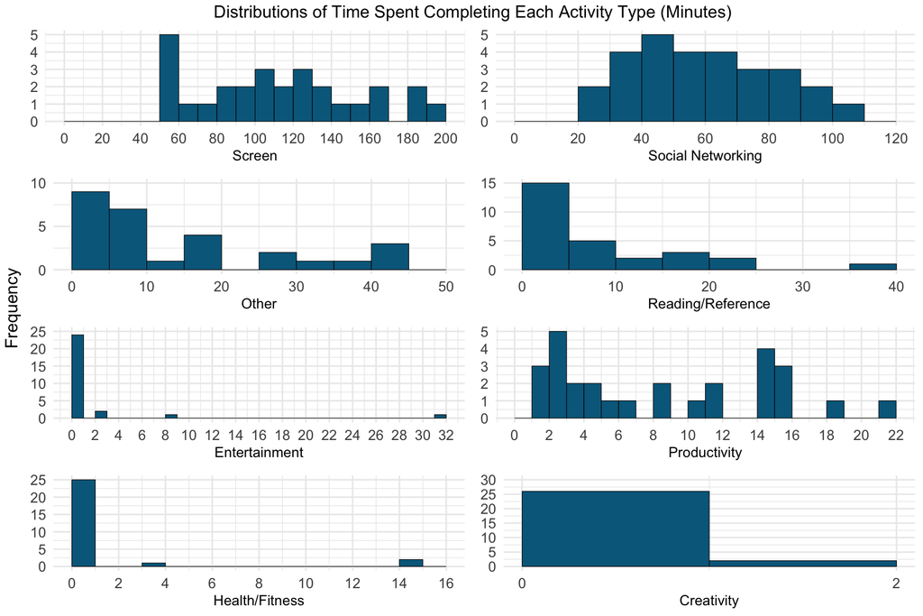

```r
hist <- grid.arrange(grobs = hist_list,
                     ncol = 2,
                     top = textGrob("Distributions of Time Spent Completing Each Activity Type (Minutes)",
                                    gp = gpar(fontsize = 12)),
                     left = textGrob("Frequency",
                                     rot = 90,
                                     gp = gpar(fontsize = 12)))
```